# STATS230_John_Corrette_HW_1

John Corrette

1/12/2022

## Github

The public Github repository for this R package, jcorrett/stats230.Rpackage, can be found online [here](https://github.com/jcorrett/stats230.Rpackage).

The package data is stored under the folder named mainProject, to compile and install the library, load mainProject, and use the package devtools to build and install, and the package should be installed under the name stats230.Rpackage.

## Test Function

For our multiplication function, we want to verify that we compute the products correctly. For this to be the case, we know that
$$A\cdot (B\cdot\boldsymbol{x}) = (A\cdot B)\cdot\boldsymbol{x}.$$
So, to check that our function is working correctly, we compute
$$||A\cdot (B\cdot\boldsymbol{x}) - (A\cdot B)\cdot\boldsymbol{x}||_\infty = \varepsilon.$$
If our function is working correctly, we should find that $\varepsilon \approx 1e-16$, the machine’s working precision. We compute this value as follows on dense matrices $A,B \in \mathbb{R}^{10\times 10}$ and vector $\boldsymbol{x}\in\mathbb{R}^{10}$, where each entry of these matrices and vector is a random number drawn from a standard normal distribution. This does not guarantee that our matrices are full rank, but does ensure that they are dense and that little to no trivial computations are performed by the algorithm.

```r
n <- 10
Atest <- matrix(rnorm(n^2),nrow=n,ncol=n)
Btest <- matrix(rnorm(n^2),nrow=n,ncol=n)
xtest <- matrix(rnorm(n^2),nrow=n,ncol=1)
prod1 <- matrixvectormultiply(Atest,Btest,xtest,TRUE)
prod2 <- matrixvectormultiply(Atest,Btest,xtest,FALSE)
error <- norm(prod1-prod2,type="I")
error
```

```
## [1] 5.329071e-15
```

We see above that our error is in fact on the order of the machine precision, so we conclude that our algorithm is working correctly and we can continue with microbenchmarking.

## Microbenchmarking

To microbenchmark this code, we will record the median computation time for a call with variable sized inputs, where $A,B \in \mathbb{R}^{n\times n}$, where $n \in [1,40]$, giving us 40 mean computation times for each way of computing $A\cdot B\cdot\boldsymbol{x}$. We can summarize the function performance with just the median computation time since each function call has only two matrix-matrix or matrix-vector multiplications, so the structure is simple enough to use one time measurement to summarize the whole function call. Then, using the bench package, we compute the median computation time as a function of $n$ for each algorithm as follows.

```r
nmax <- 40
A <- matrix(rnorm(nmax^2),nrow=nmax,ncol=nmax)
B <- matrix(rnorm(nmax^2),nrow=nmax,ncol=nmax)
x <- matrix(rnorm(nmax^2),nrow=nmax,ncol=1)
method1_median <- c()
method2_median <- c()
nvec <- 1:nmax
for (n in nvec) {
  lb <- mark(matrixvectormultiply(A[1:n,1:n],B[1:n,1:n],matrix(x[1:n]),TRUE),matrixvectormultiply(A[1:n,1:n],B[1:n,1:n],matrix(x[1:n]),FALSE))
  method1_median[n] <- lb$median[1]
  method2_median[n] <- lb$median[2]
}

df <- data.frame(nvec,method1_median,method2_median)
```

Using the above data, we then summarize our results in the following plot:

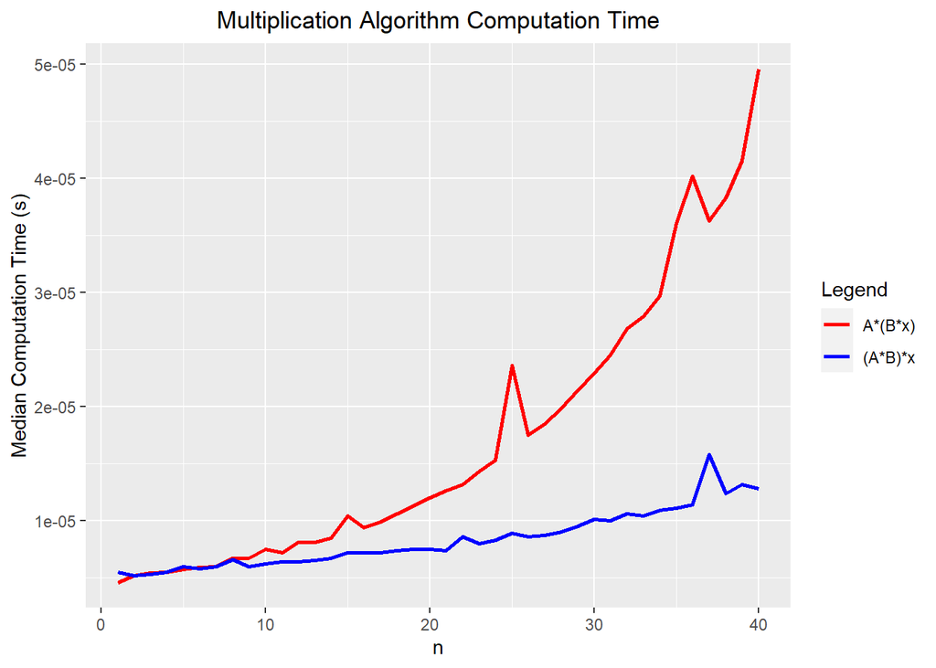